# PA1_template

Fides

2/25/2021

# 1-Loading and preprocessing the data

### a) Load the data and packages

```r
activity <- read.csv(file="~/Desktop/activity.csv", header=TRUE, sep=",", na.strings = "NA")

library("dplyr")
```

```r
library("ggplot2")
library("data.table")
library("lubridate")
library("httpuv")
```

### b) Pre-process the data

##Unify date class

```r
activity$date <- ymd(activity$date)
```

##Remove missing values

```r
activity1 <- na.omit(activity)
```

##Create new variables

```r
activity$monthly <- as.numeric(format(activity$date, "%m"))
activity$daily <- as.numeric(format(activity$date, "%d"))
```

##Check data

```r
summary(activity1)
```

```
##      steps             date               interval
##  Min.   :  0.00   Min.   :2010-02-12   Min.   :   0.0
##  1st Qu.:  0.00   1st Qu.:2010-06-12   1st Qu.: 588.8
##  Median :  0.00   Median :2010-11-27   Median :1177.5
##  Mean   : 37.26   Mean   :2010-12-16   Mean   :1177.5
##  3rd Qu.: 15.00   3rd Qu.:2011-06-12   3rd Qu.:1766.2
##  Max.   :802.00   Max.   :2011-12-12   Max.   :2355.0
```

## 2-Calculate total number of steps

### a) Make summary of data for ggplot

```r
activity2 <- summarize(group_by(activity1, date), daily.step=sum(steps))
mean.activity <- as.integer(mean(activity2$daily.step))
median.activity <- as.integer(median(activity2$daily.step))
```

### b) Make a histogram of the total number of steps taken each day

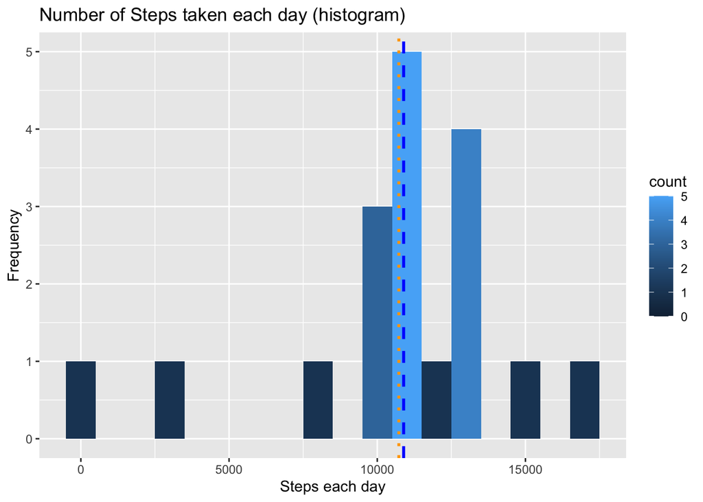

```r
plot.steps.day <- ggplot(activity2, aes(x=daily.step)) +
  geom_histogram(binwidth = 1000, aes(y=..count.., fill=..count..)) +
  geom_vline(xintercept=mean.activity, colour="orange", linetype="dotted", size=1) +
  geom_vline(xintercept=median.activity, colour="blue" , linetype="dashed", size=1) +
  labs(title="Number of Steps taken each day (histogram)", y="Frequency", x="Steps each day")
plot.steps.day
```

### c) Mean total number of steps taken per day

```r
mean.activity
```

```
## [1] 10729
```

### c) Median total number of steps taken per day

```r
median.activity
```

```
## [1] 10890
```

## 3-What is the average daily activity pattern?

##Prepare data for ggplot

```r
activity3 <- activity1 %>%
        group_by(interval) %>%
        summarize(mean.step=mean(steps))
```

### a) Make a time series plot (i.e. type = “l”) of the 5-minute interval (x-axis) and the average number of steps taken, averaged across all days (y-axis)

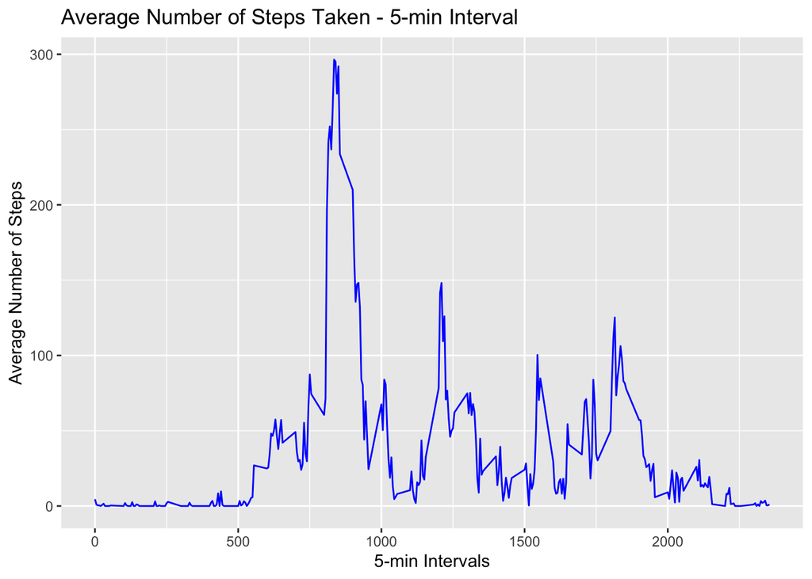

```r
plot.step.interval <- ggplot(activity3, aes(x=interval,y=mean.step)) +
  geom_line(color="blue") +
  labs(title="Average Number of Steps Taken - 5-min Interval", y="Average Number of Steps", x="5-min Intervals")
plot.step.interval
```

### b) Which 5-minute interval, on average across all the days in the dataset, contains the maximum number of steps?

```r
optimal <- which.max(activity3$mean.step)
optimal.step <- activity3$interval[optimal]
sprintf("%gth 5-min interval has maximum number of steps", optimal.step)
```

```
## [1] "835th 5-min interval has maximum number of steps"
```

## 4-Imputing missing values

### a) Total number of missing values in dataset

```r
sum(is.na(activity))
```

```
## [1] 34272
```

### b) Devise a strategy for filling in all of the missing values in the dataset. The strategy does not need to be sophisticated. For example, you could use the mean/median for that day, or the mean for that 5-minute interval, etc.

```r
impute.activity <- activity
impute.activity$steps[is.na(impute.activity$steps)] <- mean(impute.activity$steps,na.rm=TRUE)
impute.activity$steps <- as.numeric(impute.activity$steps)
impute.activity$interval <- as.numeric(impute.activity$interval)
colSums(is.na(impute.activity))
```

```
##    steps     date interval  monthly    daily
##        0    10656        0    10656    10656
```

```r
summary(impute.activity)
```

```
##      steps             date               interval         monthly
##  Min.   :  0.00   Min.   :2010-01-12   Min.   :   0.0   Min.   : 1.00
##  1st Qu.:  0.00   1st Qu.:2010-07-04   1st Qu.: 588.8   1st Qu.: 3.75
##  Median :  0.00   Median :2010-12-27   Median :1177.5   Median : 6.50
##  Mean   : 37.38   Mean   :2010-12-27   Mean   :1177.5   Mean   : 6.50
##  3rd Qu.: 37.38   3rd Qu.:2011-06-19   3rd Qu.:1766.2   3rd Qu.: 9.25
##  Max.   :806.00   Max.   :2011-12-12   Max.   :2355.0   Max.   :12.00
##                   NA's   :10656                         NA's   :10656
##      daily
##  Min.   :12
##  1st Qu.:12
##  Median :12
##  Mean   :12
##  3rd Qu.:12
##  Max.   :12
##  NA's   :10656
```

##Summarize data by date

```r
impute.activity2 <- summarize(group_by(impute.activity,date),daily.step=sum(steps))
mean.impute   <- as.integer(mean(impute.activity2$daily.step))
mean.impute
```

```
## [1] 26269
```

```r
median.impute <- as.integer(median(impute.activity2$daily.step))
median.impute
```

```
## [1] 10766
```